# Análisis exploratorio por Componentes Principales y Clúster

Gorriones

Edimer David Jaramillo

Junio de 2018

# Análisis de Componentes Principales (ACP)

## Generalidades

- El ACP se constituye como una técnica exploratoria, en etapas iniciales del análisis de los datos.
- Su propósito fundamental es reducir la dimensión de un conjunto de datos.
- Transforma las variables originales en un conjunto de variables más pequeñas, las cuales son combinaciones lineales de las variables originales y retienen la mayor parte de la variabilidad presente en estas.
- Convierte un conjunto de variables posiblemente correlacionadas, en un conjunto de variables sin correlación lineal, denominadas *Componentes Principales (CP).*

## Objetivos del ACP

- Obtener nuevas variables (componentes principales) que expresen la información contenida en los datos originales.
- Reducir la dimensionalidad de los datos.
- Reconocer patrones de comportamiento presentes en los datos.
- Contribuir a la interpretación de la información que poseen los datos.

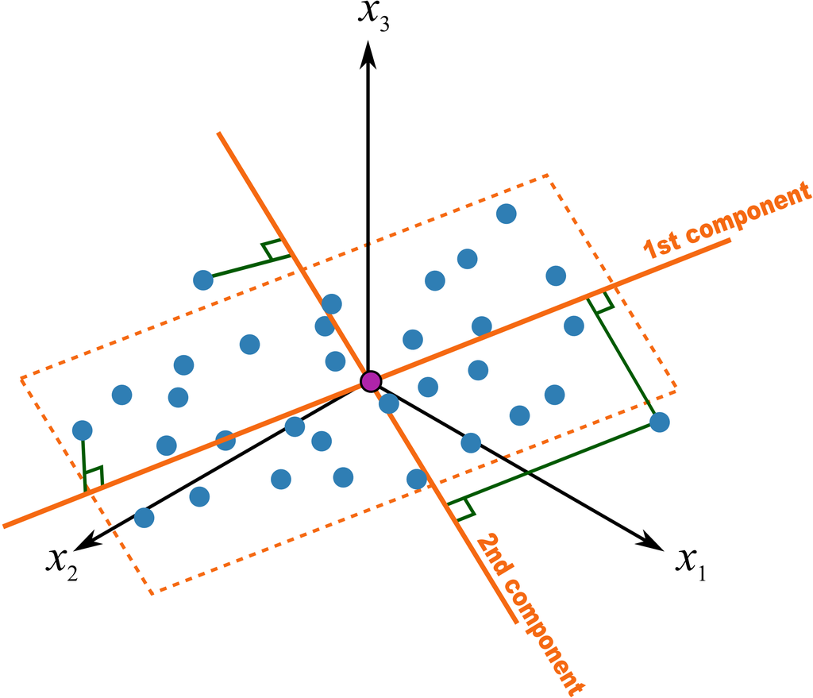

- Nuevo sistema de coordenadas.
- Obtención de direcciones ortogonales (o componentes principales) con máxima variabilidad.
- Las nuevas direcciones proporcionan una dispersión simple y parsimoniosa de la estructura de covarianza de los datos.
- Las *componentes principales* se pueden obtener a través de la matriz de varianzas-covarianzas o de la matriz de correlación.

# Análisis de Clúster

## Generalidades

- Procedimiento que tiene como punto de partida un conjunto de datos que contiene información sobre una muestra de individuos e intenta reorganizarlos en grupos relativamente homogéneos a los que se llama conglomerados (clusters).
- Un conglomerado, grupo o clase es un conjunto de individuos con características similares.
- Es necesario una medida que indique la similaridad entre individuos u objetos.
- Es necesario un método para obtener los grupos

## Objetivos del Cluster

- Clasificación
- Busca particionar un cojunto de objetos en grupos, de tal forma que los objetos de un mismo grupo sean similares y los objetos de grupos distintos sean diferentes.

## Medidas de similaridad

- **Métricas:** distancias
- **Escala nominal** coeficientes de asociación
- **Coeficientes de correlación**

## Métodos de agrupamiento

- Métodos jerarquicos
- Métodos no jerarquicos o de partición
- Métodos de nubes dinámicas
- Métodos de clasificación difusa

**Los métodos jerarquicos se clasifican en:**

- Aglomerativos
- Desaglomerativos

**Algunos de los métodos jerarquicos aglomerativos son:**

- Método de enlace simple o vecino más cercano
- Metodo de enlace completo o vecino más lejano
- Método de enlace promedio
- Método de Ward

# Ejemplo

**Descripción del conjunto de datos (Gorriones.csv):** " … el 1 de febrero del presente año (1898), cuando, después de una tormenta extraordinariamente severa de nieve, lluvia y aguanieve, varios gorriones ingleses fueron llevados al Laboratorio Anatómico de la Universidad de Brown. Setenta y dos de estas aves revivieron; sesenta y cuatro perecieron; … “.” … la tormenta fue de larga duración, y las aves fueron recogidas, no en una localidad, sino en varias localidades; … “. **Este evento fue descrito por Hermon Bumpus (1898) como un ejemplo clásico de la selección natural en acción.** [Artículo científico](https://onlinelibrary.wiley.com/doi/pdf/10.1111/j.1558-5646.1972.tb00171.x)

## Descripción de variables

- **Sexo:** Machos (m) y hembras (f)
- **Edad:** Adulto (a) y joven (y)
- **Sobrevivió:** Sí (SI) y no (NO)
- **Longitud total (mm):** `LongitudTotal` (desdel la punta del pico hasta la punta de la cola)
- **Extensión de las alas (mm):** `ExteAlas` (de punta a punta de las alas extendidas)
- **Peso (gr):** peso del ave
- **Longitud del pico y la cabeza (mm):** `LonPicoCabe`
- **Longitud del húmero (pulgadas):** `LonHumero`
- **Longitud del fémur (pulgadas):** `LonFemur`
- **Longitud de tibia-tarso (pulgadas):** `LonTibTarso`
- **Ancho del cráneo (pulgadas):** `AncCraneo`
- **Longitud de la quilla (pulgadas):** `LonQuilla`

## Lectura de datos

```r
datos <- read.csv(file = "data//Gorriones.csv", dec = ",")
datos
```

| Sexo | Edad | Sobrevivio | LongitudTotal | ExteAlas | Peso | LonPicoCabe | LonHumero | LonFemur | LonTibTarso | AncCraneo | LonQuilla |
| --- | --- | --- | --- | --- | --- | --- | --- | --- | --- | --- | --- |
| m | a | SI | 154 | 241 | 24.5 | 31.2 | 0.687 | 0.668 | 1.022 | 0.587 | 0.830 |
| m | a | NO | 165 | 240 | 26.5 | 31.0 | 0.738 | 0.704 | 1.095 | 0.606 | 0.847 |
| m | a | NO | 160 | 245 | 26.1 | 32.0 | 0.736 | 0.709 | 1.109 | 0.611 | 0.842 |
| m | a | SI | 160 | 252 | 26.9 | 30.8 | 0.736 | 0.709 | 1.180 | 0.602 | 0.841 |
| m | a | SI | 155 | 243 | 26.9 | 30.6 | 0.733 | 0.704 | 1.151 | 0.602 | 0.846 |
| m | a | NO | 161 | 249 | 25.6 | 32.3 | 0.743 | 0.718 | 1.128 | 0.602 | 0.828 |
| m | a | SI | 154 | 245 | 24.3 | 31.7 | 0.741 | 0.688 | 1.146 | 0.584 | 0.839 |
| m | a | NO | 162 | 246 | 25.9 | 32.3 | 0.738 | 0.709 | 1.135 | 0.607 | 0.869 |
| m | a | SI | 156 | 247 | 24.1 | 31.5 | 0.715 | 0.706 | 1.129 | 0.575 | 0.821 |
| m | a | NO | 163 | 250 | 25.5 | 32.5 | 0.752 | 0.731 | 1.197 | 0.623 | 0.888 |

[output cut: 126 more lines]

## Resumen de datos

```r
summary(datos[, 4:12])
```

```
##  LongitudTotal      ExteAlas          Peso        LonPicoCabe
##  Min.   :152.0   Min.   :230.0   Min.   :22.60   Min.   :29.80
##  1st Qu.:157.0   1st Qu.:242.0   1st Qu.:24.57   1st Qu.:31.10
##  Median :160.0   Median :246.0   Median :25.55   Median :31.60
##  Mean   :159.5   Mean   :245.2   Mean   :25.52   Mean   :31.57
##  3rd Qu.:162.0   3rd Qu.:249.0   3rd Qu.:26.50   3rd Qu.:32.02
##  Max.   :167.0   Max.   :256.0   Max.   :31.00   Max.   :33.40
##    LonHumero         LonFemur       LonTibTarso      AncCraneo
##  Min.   :0.6590   Min.   :0.6530   Min.   :1.011   Min.   :0.5510
##  1st Qu.:0.7177   1st Qu.:0.7017   1st Qu.:1.112   1st Qu.:0.5920
##  Median :0.7330   Median :0.7130   Median :1.133   Median :0.6020
##  Mean   :0.7319   Mean   :0.7130   Mean   :1.134   Mean   :0.6025
##  3rd Qu.:0.7482   3rd Qu.:0.7312   3rd Qu.:1.162   3rd Qu.:0.6110
##  Max.   :0.7800   Max.   :0.7670   Max.   :1.230   Max.   :0.6400
##    LonQuilla
##  Min.   :0.7340
##  1st Qu.:0.8090
##  Median :0.8410
##  Mean   :0.8399
##  3rd Qu.:0.8652
##  Max.   :0.9270
```

## Matriz de dispersión y correlación (gráfico)

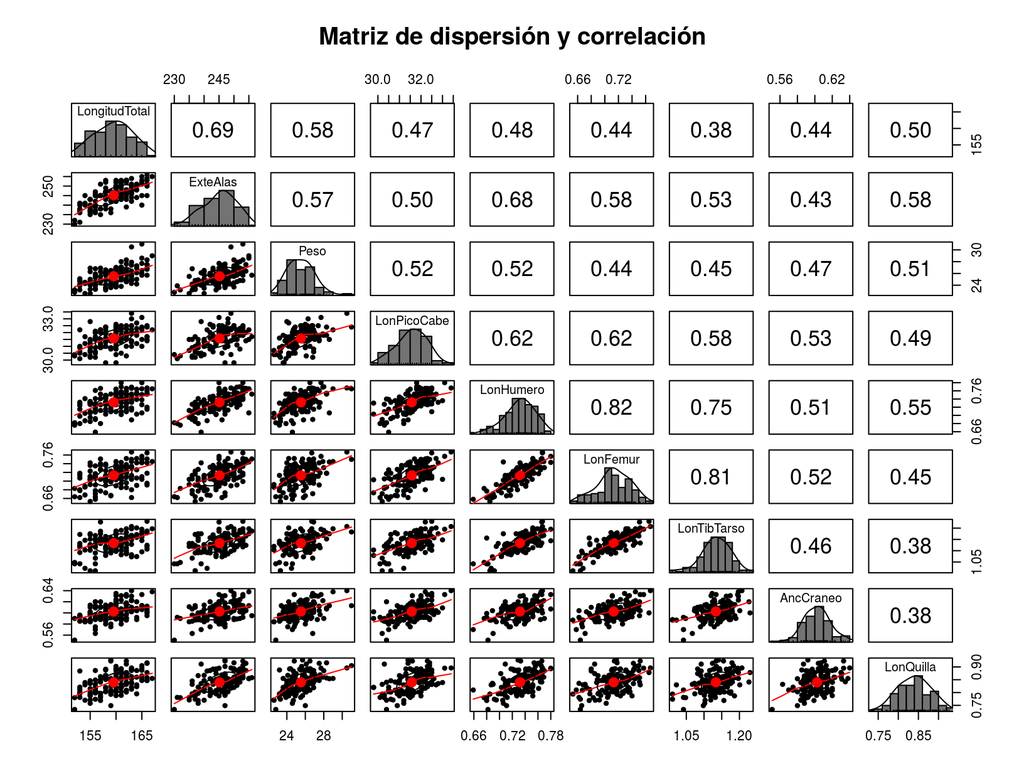

```r
library(psych)
pairs.panels(datos[, 4:12],
             hist.col = "gray45",
             density = TRUE,
             main = "Matriz de dispersión y correlación")
```

## Matriz de correlaciones

```r
cor(datos[, 4:12])
```

```
##               LongitudTotal  ExteAlas      Peso LonPicoCabe LonHumero
## LongitudTotal     1.0000000 0.6909709 0.5838648   0.4694466 0.4846190
## ExteAlas          0.6909709 1.0000000 0.5686500   0.4990738 0.6779536
## Peso              0.5838648 0.5686500 1.0000000   0.5192088 0.5188943
## LonPicoCabe       0.4694466 0.4990738 0.5192088   1.0000000 0.6229937
## LonHumero         0.4846190 0.6779536 0.5188943   0.6229937 1.0000000
## LonFemur          0.4447051 0.5782836 0.4441451   0.6164174 0.8205803
## LonTibTarso       0.3776146 0.5316798 0.4544589   0.5843728 0.7460385
## AncCraneo         0.4355363 0.4338913 0.4714846   0.5347534 0.5120226
## LonQuilla         0.5008898 0.5801525 0.5126353   0.4903663 0.5486094
##                LonFemur LonTibTarso AncCraneo LonQuilla
## LongitudTotal 0.4447051   0.3776146 0.4355363 0.5008898
## ExteAlas      0.5782836   0.5316798 0.4338913 0.5801525
## Peso          0.4441451   0.4544589 0.4714846 0.5126353
## LonPicoCabe   0.6164174   0.5843728 0.5347534 0.4903663
## LonHumero     0.8205803   0.7460385 0.5120226 0.5486094
## LonFemur      1.0000000   0.8092996 0.5212480 0.4536862
## LonTibTarso   0.8092996   1.0000000 0.4586951 0.3840558
## AncCraneo     0.5212480   0.4586951 1.0000000 0.3840089
## LonQuilla     0.4536862   0.3840558 0.3840089 1.0000000
```

## Cálculo de las *componentes principales*

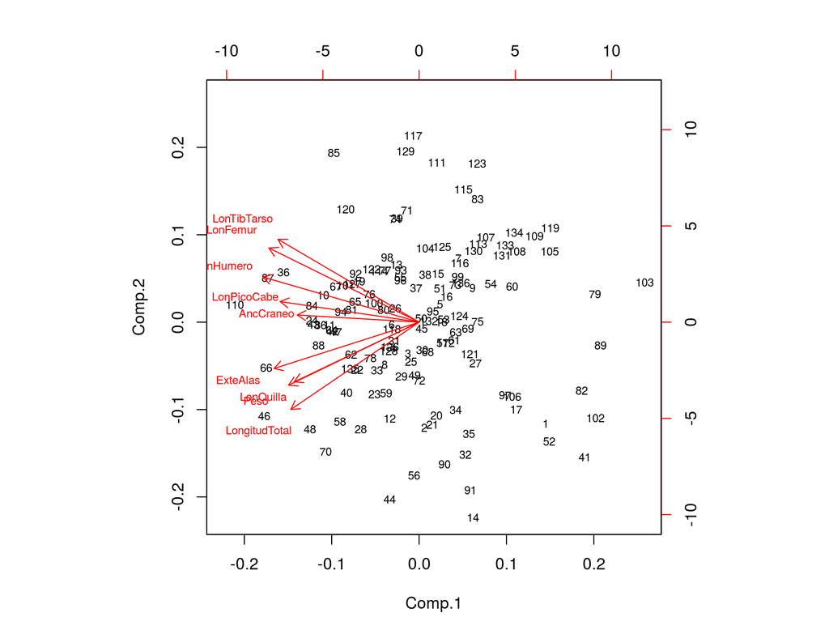

```r
acp <- princomp(datos[, 4:12], scale = TRUE, cor = TRUE)
biplot(acp, cex = 0.7)
```

## Proporción de varianza

```r
summary(acp)
```

```
## Importance of components:
##                           Comp.1    Comp.2     Comp.3     Comp.4
## Standard deviation     2.3046882 0.9988978 0.81280426 0.73068317
## Proportion of Variance 0.5901764 0.1108663 0.07340564 0.05932199
## Cumulative Proportion  0.5901764 0.7010427 0.77444838 0.83377037
##                            Comp.5     Comp.6     Comp.7     Comp.8
## Standard deviation     0.67837980 0.63624854 0.52104550 0.46168667
## Proportion of Variance 0.05113324 0.04497913 0.03016538 0.02368384
## Cumulative Proportion  0.88490361 0.92988274 0.96004812 0.98373196
##                            Comp.9
## Standard deviation     0.38263868
## Proportion of Variance 0.01626804
## Cumulative Proportion  1.00000000
```

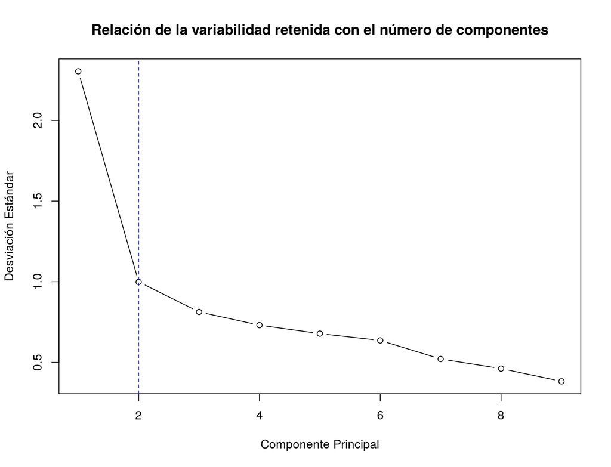

```r
plot(acp$sdev, type="b", xlab = "Componente Principal",
     ylab = "Desviación Estándar",
     main = "Relación de la variabilidad retenida con el número de componentes")
abline(v = 2, col = "blue", lty = 2, lwd = 0.8)
```

## Importancia de variables sobre las componentes

```r
loadings(acp)[,1:9]
```

```
##                   Comp.1      Comp.2      Comp.3      Comp.4     Comp.5
## LongitudTotal -0.3100651 -0.48676787 -0.05636978  0.45377621  0.1326996
## ExteAlas      -0.3505712 -0.25833261 -0.33786910  0.25610634  0.2419548
## Peso          -0.3155630 -0.35142457  0.19791968  0.07935593 -0.7038798
## LonPicoCabe   -0.3358877  0.11469994  0.29286266 -0.30567863 -0.3264084
## LonHumero     -0.3779134  0.25196559 -0.22209147 -0.02197200  0.0837826
## LonFemur      -0.3628170  0.41308546 -0.14264156  0.07732550  0.0761244
## LonTibTarso   -0.3408942  0.46175891 -0.15231419  0.13796632 -0.1776658
## AncCraneo     -0.2946541  0.03996533  0.78349062  0.04854279  0.4795809
## LonQuilla     -0.3017853 -0.33274799 -0.22582687 -0.77518179  0.2179036
##                    Comp.6      Comp.7      Comp.8      Comp.9
## LongitudTotal  0.36031440  0.51853028 -0.13136187 -0.15575960
## ExteAlas       0.02384397 -0.64295510  0.33808212  0.20932445
## Peso          -0.46084211 -0.06240530 -0.10097266  0.09766796
## LonPicoCabe    0.73723935 -0.20681677  0.04051399  0.01834518
## LonHumero     -0.11938625 -0.25053953 -0.58145771 -0.56723163
## LonFemur      -0.04231837  0.23333115 -0.31239139  0.71538857
## LonTibTarso   -0.13117472  0.30096834  0.63401809 -0.29496225
## AncCraneo     -0.23554995 -0.04561749  0.08045686 -0.03649455
## LonQuilla     -0.15802907  0.24736838  0.11168704  0.01339906
```

## Puntajes de los invidividuos sobre las componentes

```r
head(acp$scores, n = 10)
```

```
##           Comp.1     Comp.2      Comp.3     Comp.4      Comp.5     Comp.6
##  [1,]  3.8880757 -1.3522616  0.41603544 -1.1326393 -0.09606579  0.3027823
##  [2,]  0.1575123 -1.4096787  0.40722779  0.4664938  0.09095160 -0.3538219
##  [3,] -0.3388752 -0.4201252  0.77208305 -0.2187090 -0.07081691  0.2364849
##  [4,] -0.7918721 -0.3448695 -0.78499927  0.9062612 -0.19145687 -1.3317598
##  [5,]  0.6448564  0.2402161 -0.09755562 -0.2748429 -0.55333926 -1.9911962
##  [6,] -0.8439208 -0.0350315 -0.01554790  0.2697300 -0.15319876  0.9125169
##  [7,]  1.1956308  0.8519471 -0.96170268 -0.9277625 -0.38677427  0.2045844
##  [8,] -1.0570477 -0.5649736  0.29651557 -0.5145504 -0.08213999  0.6833607
##  [9,]  1.6455690  0.4574013 -1.38797615 -0.1532863 -0.38641002  0.6405087
## [10,] -2.9531850  0.3580806  0.29672513 -0.3620770  0.69724960  0.4983349
##           Comp.7       Comp.8      Comp.9
##  [1,] -0.9560481 -0.135479587  0.61889581
##  [2,]  1.1263744 -1.220505643 -0.53167046
##  [3,] -0.3398357 -0.425679302 -0.03965116
##  [4,] -0.2897437  0.937730100 -0.24581620
##  [5,] -0.1090226  0.260215062 -0.23649302
##  [6,] -0.6368404 -0.250486007  0.01779123
##  [7,] -0.9721672  0.473395099 -0.85628752
##  [8,]  0.1076841  0.003133374 -0.31415922
##  [9,] -0.5991745  0.582995122  0.43028359
## [10,]  0.3350900  0.719128185 -0.40058705
```

## Concatenando resultados

```r
datos2 <- data.frame(datos, acp$scores[, c(1, 2)])
datos2
```

| Sexo | Edad | Sobrevivio | LongitudTotal | ExteAlas | Peso | LonPicoCabe | LonHumero | LonFemur | LonTibTarso | AncCraneo | LonQuilla | Comp.1 | Comp.2 |
| --- | --- | --- | --- | --- | --- | --- | --- | --- | --- | --- | --- | --- | --- |
| m | a | SI | 154 | 241 | 24.5 | 31.2 | 0.687 | 0.668 | 1.022 | 0.587 | 0.830 | 3.88807570 | -1.352261611 |
| m | a | NO | 165 | 240 | 26.5 | 31.0 | 0.738 | 0.704 | 1.095 | 0.606 | 0.847 | 0.15751228 | -1.409678688 |
| m | a | NO | 160 | 245 | 26.1 | 32.0 | 0.736 | 0.709 | 1.109 | 0.611 | 0.842 | -0.33887522 | -0.420125206 |
| m | a | SI | 160 | 252 | 26.9 | 30.8 | 0.736 | 0.709 | 1.180 | 0.602 | 0.841 | -0.79187214 | -0.344869540 |
| m | a | SI | 155 | 243 | 26.9 | 30.6 | 0.733 | 0.704 | 1.151 | 0.602 | 0.846 | 0.64485645 | 0.240216083 |
| m | a | NO | 161 | 249 | 25.6 | 32.3 | 0.743 | 0.718 | 1.128 | 0.602 | 0.828 | -0.84392083 | -0.035031497 |
| m | a | SI | 154 | 245 | 24.3 | 31.7 | 0.741 | 0.688 | 1.146 | 0.584 | 0.839 | 1.19563079 | 0.851947079 |
| m | a | NO | 162 | 246 | 25.9 | 32.3 | 0.738 | 0.709 | 1.135 | 0.607 | 0.869 | -1.05704767 | -0.564973560 |
| m | a | SI | 156 | 247 | 24.1 | 31.5 | 0.715 | 0.706 | 1.129 | 0.575 | 0.821 | 1.64556903 | 0.457401298 |
| m | a | NO | 163 | 250 | 25.5 | 32.5 | 0.752 | 0.731 | 1.197 | 0.623 | 0.888 | -2.95318503 | 0.358080615 |

[output cut: 126 more lines]

## Proyección de aves sobre CP1 y CP2

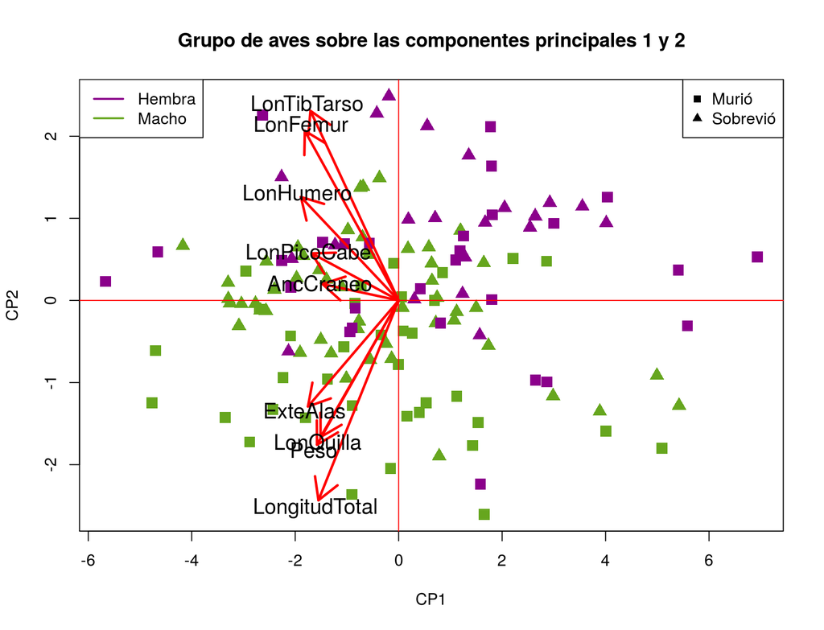

```r
color <- c("magenta4",  "#66A61E")
simbolos <- c(15, 17)
with(datos2, plot(Comp.1, Comp.2, col = color[Sexo],
                  pch = simbolos[Sobrevivio],
                  cex = 1.5,  xlab = "CP1",
                  ylab = "CP2",
                  main = "Grupo de aves sobre las componentes principales 1 y 2"))
legend("topleft", legend = c("Hembra", "Macho"), col = color, cex = 1, lwd =2)
legend("topright", legend = c("Murió", "Sobrevió"), pch = simbolos,
       col = "black", cex = 1)
abline(h = 0, col = "red")
abline(v = 0, col = "red")
arrows(0, 0,
       acp$loadings[, 1]*5,
       acp$loadings[, 2]*5,
       col = "red",
       lwd = 2.5)
text(acp$loadings[, 1]*5.2,
     acp$loadings[, 2]*5.2,
     row.names(acp$loadings),
     cex = 1.3)
```

## Dendrograma (enlace completo o vecino más lejano)

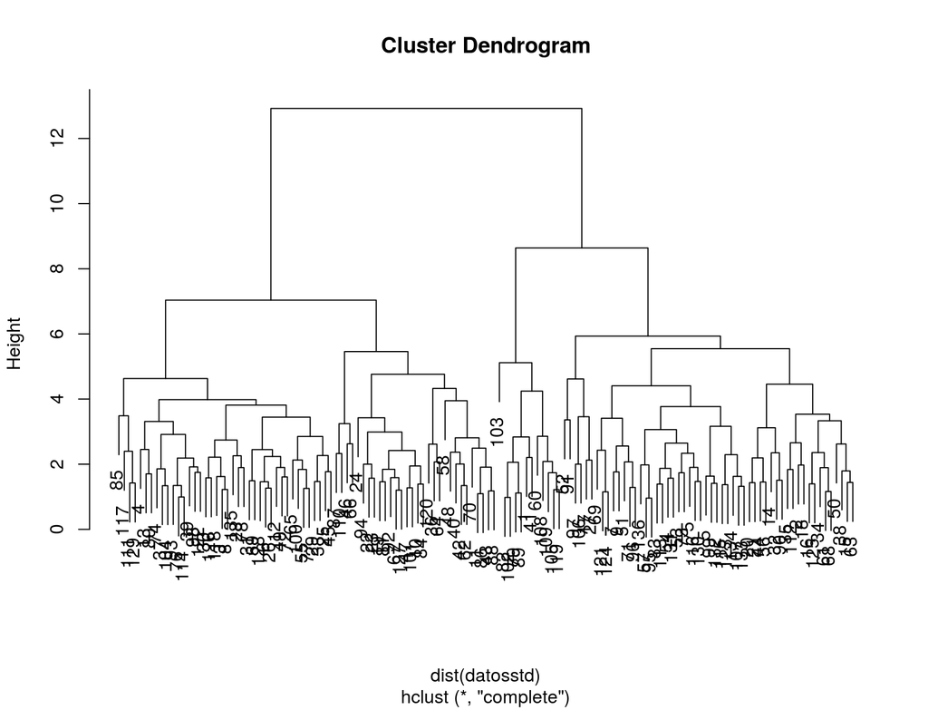

```r
datosstd <- data.frame(scale(datos[, 4:12]))
cluster1 <- hclust(dist(datosstd))
plot(cluster1)
```

## Concatenando clúster con la base de datos

```r
datos2$grupo <- cutree(cluster1, 5)
datos2
```

| Sexo | Edad | Sobrevivio | LongitudTotal | ExteAlas | Peso | LonPicoCabe | LonHumero | LonFemur | LonTibTarso | AncCraneo | LonQuilla | Comp.1 | Comp.2 | grupo |
| --- | --- | --- | --- | --- | --- | --- | --- | --- | --- | --- | --- | --- | --- | --- |
| m | a | SI | 154 | 241 | 24.5 | 31.2 | 0.687 | 0.668 | 1.022 | 0.587 | 0.830 | 3.88807570 | -1.352261611 | 1 |
| m | a | NO | 165 | 240 | 26.5 | 31.0 | 0.738 | 0.704 | 1.095 | 0.606 | 0.847 | 0.15751228 | -1.409678688 | 2 |
| m | a | NO | 160 | 245 | 26.1 | 32.0 | 0.736 | 0.709 | 1.109 | 0.611 | 0.842 | -0.33887522 | -0.420125206 | 3 |
| m | a | SI | 160 | 252 | 26.9 | 30.8 | 0.736 | 0.709 | 1.180 | 0.602 | 0.841 | -0.79187214 | -0.344869540 | 3 |
| m | a | SI | 155 | 243 | 26.9 | 30.6 | 0.733 | 0.704 | 1.151 | 0.602 | 0.846 | 0.64485645 | 0.240216083 | 2 |
| m | a | NO | 161 | 249 | 25.6 | 32.3 | 0.743 | 0.718 | 1.128 | 0.602 | 0.828 | -0.84392083 | -0.035031497 | 3 |
| m | a | SI | 154 | 245 | 24.3 | 31.7 | 0.741 | 0.688 | 1.146 | 0.584 | 0.839 | 1.19563079 | 0.851947079 | 2 |
| m | a | NO | 162 | 246 | 25.9 | 32.3 | 0.738 | 0.709 | 1.135 | 0.607 | 0.869 | -1.05704767 | -0.564973560 | 3 |
| m | a | SI | 156 | 247 | 24.1 | 31.5 | 0.715 | 0.706 | 1.129 | 0.575 | 0.821 | 1.64556903 | 0.457401298 | 2 |
| m | a | NO | 163 | 250 | 25.5 | 32.5 | 0.752 | 0.731 | 1.197 | 0.623 | 0.888 | -2.95318503 | 0.358080615 | 4 |

[output cut: 126 more lines]

**Resumen numérico para cada clúster o grupo**

```r
lapply(split(datos2[, 4:12], datos2$grupo), FUN = summary)
```

```
## $`1`
##  LongitudTotal      ExteAlas          Peso        LonPicoCabe
##  Min.   :152.0   Min.   :230.0   Min.   :22.60   Min.   :30.10
##  1st Qu.:153.0   1st Qu.:234.2   1st Qu.:23.10   1st Qu.:30.38
##  Median :154.5   Median :237.0   Median :23.30   Median :30.55
##  Mean   :154.3   Mean   :236.2   Mean   :23.61   Mean   :30.64
##  3rd Qu.:155.2   3rd Qu.:238.2   3rd Qu.:24.52   3rd Qu.:30.98
##  Max.   :157.0   Max.   :241.0   Max.   :24.70   Max.   :31.20
##    LonHumero         LonFemur       LonTibTarso      AncCraneo
##  Min.   :0.6590   Min.   :0.6530   Min.   :1.011   Min.   :0.5510
##  1st Qu.:0.6800   1st Qu.:0.6635   1st Qu.:1.037   1st Qu.:0.5840
##  Median :0.6860   Median :0.6725   Median :1.045   Median :0.5875
##  Mean   :0.6871   Mean   :0.6739   Mean   :1.069   Mean   :0.5847
##  3rd Qu.:0.6957   3rd Qu.:0.6837   3rd Qu.:1.107   3rd Qu.:0.5905
##  Max.   :0.7060   Max.   :0.7020   Max.   :1.156   Max.   :0.5990
##    LonQuilla
##  Min.   :0.7340
##  1st Qu.:0.7698
##  Median :0.7770
##  Mean   :0.7805
##  3rd Qu.:0.7943
##  Max.   :0.8300
##
## $`2`
##  LongitudTotal      ExteAlas          Peso        LonPicoCabe
##  Min.   :153.0   Min.   :235.0   Min.   :23.20   Min.   :30.30
##  1st Qu.:156.0   1st Qu.:240.0   1st Qu.:24.20   1st Qu.:31.00
##  Median :158.5   Median :244.0   Median :24.75   Median :31.40
##  Mean   :158.6   Mean   :242.7   Mean   :24.88   Mean   :31.27
##  3rd Qu.:161.0   3rd Qu.:246.0   3rd Qu.:25.55   3rd Qu.:31.50
##  Max.   :166.0   Max.   :251.0   Max.   :27.50   Max.   :32.40
##    LonHumero         LonFemur       LonTibTarso      AncCraneo
##  Min.   :0.6890   Min.   :0.6620   Min.   :1.073   Min.   :0.5750
##  1st Qu.:0.7150   1st Qu.:0.6947   1st Qu.:1.104   1st Qu.:0.5907
##  Median :0.7260   Median :0.7050   Median :1.123   Median :0.6000
##  Mean   :0.7246   Mean   :0.7045   Mean   :1.120   Mean   :0.5991
##  3rd Qu.:0.7330   3rd Qu.:0.7130   3rd Qu.:1.131   3rd Qu.:0.6082
##  Max.   :0.7520   Max.   :0.7350   Max.   :1.175   Max.   :0.6200
##    LonQuilla
##  Min.   :0.7810
```

[output cut: 59 more lines]

```
##  Max.   :162.0   Max.   :250.0   Max.   :26.80   Max.   :30.90
##    LonHumero         LonFemur       LonTibTarso      AncCraneo
##  Min.   :0.6900   Min.   :0.6660   Min.   :1.067   Min.   :0.5630
##  1st Qu.:0.7045   1st Qu.:0.6680   1st Qu.:1.082   1st Qu.:0.5763
##  Median :0.7100   Median :0.6720   Median :1.091   Median :0.5835
##  Mean   :0.7100   Mean   :0.6775   Mean   :1.088   Mean   :0.5828
##  3rd Qu.:0.7155   3rd Qu.:0.6820   3rd Qu.:1.097   3rd Qu.:0.5893
##  Max.   :0.7300   Max.   :0.7030   Max.   :1.103   Max.   :0.6020
##    LonQuilla
##  Min.   :0.7490
##  1st Qu.:0.8117
##  Median :0.8200
##  Mean   :0.8235
##  3rd Qu.:0.8290
##  Max.   :0.9110
```

## Proyecciones en el plano con los Cluster

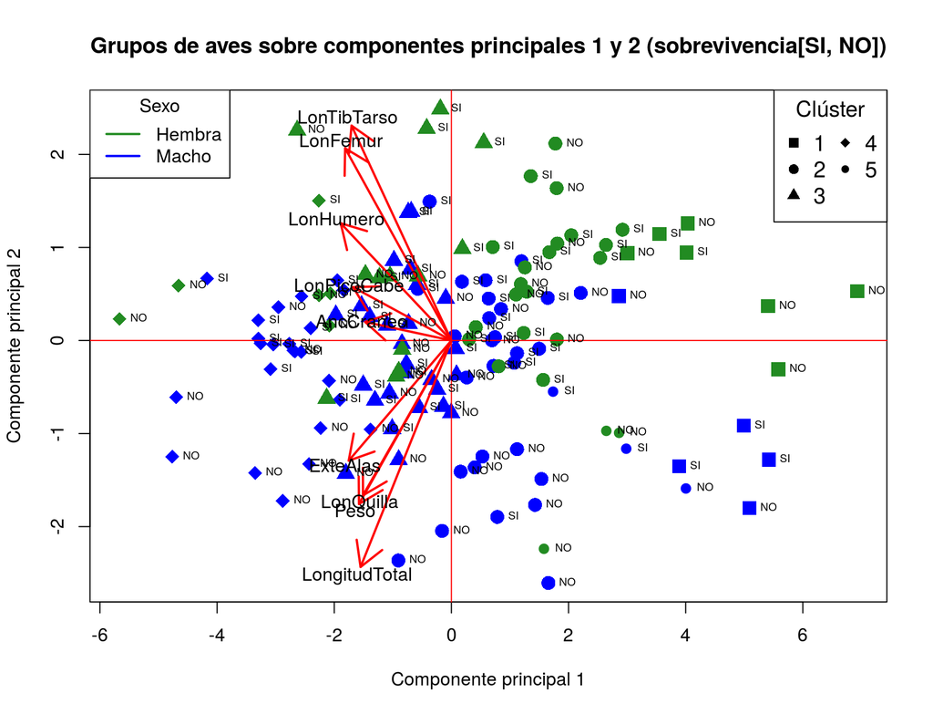

```r
colores <- c("forestgreen", "blue")
simbolos <- c(15, 16, 17, 18, 20)
with(datos2, plot(Comp.1, Comp.2, col = colores[Sexo], pch = simbolos[grupo],
                  xlab = "Componente principal 1",
                  ylab = "Componente principal 2",
                  main = "Grupos de aves sobre componentes principales 1 y 2 (sobrevivencia[SI, NO])",
                  cex = 1.7))
legend("topright", legend = 1:5, pch = simbolos, col = "black", ncol = 2,
       cex = 1.2, title = "Clúster")
legend("topleft", legend = c("Hembra", "Macho"), col = colores, cex = 1,
       lty =1, lwd =2, title = "Sexo")
abline(h = 0, col = "red")
abline(v = 0, col = "red")
arrows(0, 0, acp$loadings[, 1]*5, acp$loadings[, 2]*5, col = "red", lwd = 2)
text(acp$loadings[, 1]*5.2, acp$loadings[, 2]*5.2,
     row.names(acp$loadings))
text(datos2$Comp.1, datos2$Comp.2, labels = datos2$Sobrevivio, pos = 4,
     cex = 0.6)
```

# Recursos de información

- [5 functions to do Principal Components Analysis in R](http://www.gastonsanchez.com/visually-enforced/how-to/2012/06/17/PCA-in-R/)
- [A Little Book of R For Multivariate Analysis](http://people.stat.sc.edu/hansont/stat730/Coghlan2014.pdf)
- [Análisis multivariado de datos en R](http://www.docentes.unal.edu.co/cepardot/docs/SimposiosEstadistica/PardoOrtiz04.pdf)
- [Data Science with R: Cluster Analysis](https://onepager.togaware.com/ClustersO.pdf)